# Reproducible Pitch Presentation

Thorsten  
30 1 2020

### About the Course Project

This is a deliverable for the course Developing Data Products as part of the Coursera Data Science Specialization.

Instructions:

1. Write a shiny application with associated supporting documentation. The documentation should be thought of as whatever a user will need to get started using your application.
2. Deploy the application on Rstudio's shiny server
3. Share the application link by pasting it into the provided text box
4. Share your server.R and ui.R code on github

### The data

Using the data provided by Met Office Hadley Centre, Climate Research Unit; HadCRUT.4.4.0.0 model; median of 100 calculated time series, we fit a linear model to predict the deviation of the global air temparature deviation based to the aveage of surface temperature 1961-1990.

For the prediction model the deviation data from 1975 to 2018 have been used.

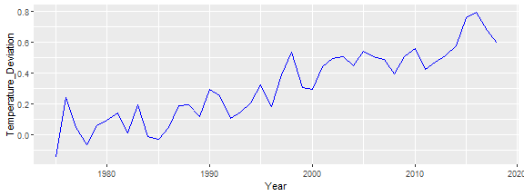

```r
dt_climate <- data.frame(Year,Temperature_Deviation)
ggplot(dt_climate, aes(Year, Temperature_Deviation)) + geom_line(color='blue')
```

### How to use the application (Documentation)

- For the prediction I used the data from 1975 to 2018 and fitted a linear model.
- The red line will show the fitted and prediction values.
- You can select a year to get the estimated predicted air temperature deviation.

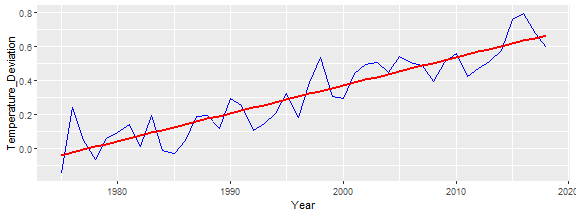

The application is running on (https://eifelmaar.shinyapps.io/Coursera_Shiny/)

### Links

- ui.R
- Server.R
- Your ReproduciblePitchPresentation.Rmd (this code) is available in github repository (https://github.com/EifelMaar/Shiny-Application-and-Reproducible-Pitch)
- YourReproduciblePitchPresentation.html is available via gh-pages (https://eifelmaar.github.io/Shiny-Application-and-Reproducible-Pitch/YourReproduciblePitchPresentation.html)